# Testing core functionalities of the ACTIONet package

Here we provide an in-depth, step-by-step guide to familiarize you with ACTIONet building blocks. For the sake of compatibility, we will use the PBMC 3k dataset used in the [Seurat](https://satijalab.org/seurat/v3.1/pbmc3k_tutorial.html) and [Scanpy](https://scanpy-tutorials.readthedocs.io/en/latest/pbmc3k.html) for this tutorial.

## Preparing the environment

To start, you need to load the ACTIONet package.

For the ACTIONet installation instruction, see ACTIONet.

```r
require(ACTIONet)
```

# Preparation

## Importing data from a `SingleCellExperiment` object

We have preprocessed and stored the PBMC 3k dataset as an `SCE` object, which is the main datatype used in the ACTIONet framework. For more information on how to convert different datatypes to `SingleCellExperiment` format, please consult our tutorial on [Bring your data along – Import/export options in ACTIONet](https://github.com/shmohammadi86/ACTIONet/tutorials/Import.html).

```r
sce = readRDS("pbmc3k_sce.RDS")

sce
```

```
class: SingleCellExperiment
dim: 1838 2638
metadata(0):
assays(1): logcounts
rownames(1838): TNFRSF4 CPSF3L ... S100B PRMT2
rowData names(1): n_cells
colnames(2638): AAACATACAACCAC-1 AAACATTGAGCTAC-1 ... TTTGCATGAGAGGC-1
  TTTGCATGCCTCAC-1
colData names(4): n_genes percent_mito n_counts louvain
reducedDimNames(4): draw_graph_fr pca tsne umap
spikeNames(0):
```

## Reducing the `SCE` object

Next, we use the `reduce.sce()` function to both normalize the counts’ matrix (lib-size normalization + log-transformation, by default) and compute a factorized (reduced) form of the kernel matrix (50 by default). By default, no batch correction is performed, and the simplest depth-normalization method is used. We then save the output for future use.

```r
sce = reduce.sce(sce = sce)
```

```
[1] "Running main reduction"
```

```r
S_r = t(reducedDims(sce)[["ACTION"]])
```

**PS**: ACTIONet includes 7 additional normalization methods (scran, linnorm, scone, SCnorm, DESeq2, TMM, and logCPM). However, the `default` method is the fastest and performs very well for ACTIONet construction.

**PS**: ACTIONet also seamlessly integrates with [Harmony](https://github.com/immunogenomics/harmony) batch-correction method. For more information on how to use batch correction please consult [To batch correct or not to batch correct, that is the question!](https://github.com/shmohammadi86/ACTIONet/tutorials/Batch.html).

## Creating an `ACTIONetExperiment (ACE)` object to hold results

We have extended the `SingleCellExperiment` class to incorporate additional slots, similar to `AnnData` format, to hold multidimensional and structural meta-data for rows and columns. To construct an `ACE` object from an `SCE` object, we run

```r
ace = as(sce, "ACTIONetExperiment")

ace
```

```
class: ACTIONetExperiment
dim: 1838 2638
metadata(1): reduction.time
assays(1): logcounts
rownames(1838): TNFRSF4 CPSF3L ... S100B PRMT2
rowData names(1): n_cells
colnames(2638): AAACATACAACCAC-1 AAACATTGAGCTAC-1 ... TTTGCATGAGAGGC-1
  TTTGCATGCCTCAC-1
colData names(4): n_genes percent_mito n_counts louvain
reducedDimNames(5): draw_graph_fr pca tsne umap ACTION
spikeNames(0):
rowNets(0):
colNets(0):
rowFactors(0):
colFactors(0):
```

As it can be seen, the new slots are `rowNets`, `colNets`, `rowFactors`, and `colFactors`. Each slot has its on getter/setter functions, which we will use through out the rest of the tutorial to store results.

# Running ACTIONet

## Running multi-level ACTION decomposition

This will run ACTIONet with increasing number of archetypes

```r
ACTION.out = run_ACTION(S_r, k_max = 30, thread_no = 8, max_it = 50, min_delta = 1e-09)
```

## Prune nonspecific and/or unreliable archetypes

To remove unreliable archetypes and a first pass filtering, we can use `prune_archetypes()` function:

```r
pruning.out = prune_archetypes(ACTION.out$C, ACTION.out$H)


C_stacked = pruning.out$C_stacked
H_stacked = pruning.out$H_stacked

colFactors(ace)[["C_stacked"]] = Matrix::t(C_stacked)
colFactors(ace)[["H_stacked"]] = H_stacked
```

`C_stacked` and `H_stacked` are the concatenated `C` and `H` matrices across different levels, respectively, after pruning noisy archetypes.

## Building ACTIONet graph

```r
set.seed(0)
G = build_ACTIONet(H_stacked = H_stacked, thread_no = 8)
```

To store computed graph as a network associated with cells (columns) in the `ACE` object, we can use:

```r
colNets(ace)$ACTIONet = G
```

## Layout ACTIONet

We have adopted and modified the SGD-based layout algorithm utilized in the *UMAP* for our visualization. We use `S_r` for our initialization:

```r
initial.coordinates = t(scale(t(S_r)))
vis.out = layout_ACTIONet(G, S_r = initial.coordinates, n_epochs = 500)
```

```r
reducedDims(ace)$ACTIONet2D = vis.out$coordinates
reducedDims(ace)$ACTIONet3D = vis.out$coordinates_3D
reducedDims(ace)$denovo_color = vis.out$colors
```

## Identiy equivalent classes of archetypes and group them together

There is a large redundancy between the set of archetypes. `unify_archetypes()` tries to coalesce these archetypes and partition them into equivalent classes.

```r
unification.out = unify_archetypes(G, S_r, pruning.out$C_stacked, pruning.out$H_stacked,
    minPoints = 10, minClusterSize = 10, outlier_threshold = 0.5)
```

And store the results back in the `ACE` object:

```r
colFactors(ace)[["C_unified"]] = t(unification.out$C_unified)
colFactors(ace)[["H_unified"]] = unification.out$H_unified
ace$assigned_archetype = unification.out$sample_assignments
```

## Use graph core of global and induced subgraphs to infer centrality/quality of each cell

We have developed a novel technique to estimate the quality of cells based on the strategic placement in the ACTIONet, w.r.t to each archetype:

```r
ace$node_centrality = compute_archetype_core_centrality(G, ace$assigned_archetype)
```

## Re-normalize input (~gene expression) matrix and compute feature (~gene) specificity scores

```r
S = assays(ace)[["logcounts"]]
norm.out = ACTIONet::renormalize_input_matrix(S, unification.out$sample_assignments)
assays(ace)[["logcounts_renorm"]] = norm.out$S_norm
```

## Compute gene specificity for each archetype

This computes the “marker-ness” of each genes for different archetypes:

```r
S.norm = norm.out$S_norm
## Core/unified archetypes only
specificity.out = compute_archetype_feature_specificity(S.norm, unification.out$H_unified)
specificity.out = lapply(specificity.out, function(specificity.scores) {
    rownames(specificity.scores) = rownames(ace)
    colnames(specificity.scores) = paste("A", 1:ncol(specificity.scores))
    return(specificity.scores)
})
rowFactors(ace)[["H_unified_profile"]] = specificity.out[["archetypes"]]
rowFactors(ace)[["H_unified_upper_significance"]] = specificity.out[["upper_significance"]]
rowFactors(ace)[["H_unified_lower_significance"]] = specificity.out[["lower_significance"]]

## All pruned archetypes
specificity.out = compute_archetype_feature_specificity(S.norm, pruning.out$H_stacked)
specificity.out = lapply(specificity.out, function(specificity.scores) {
    rownames(specificity.scores) = rownames(ace)
    colnames(specificity.scores) = paste("A", 1:ncol(specificity.scores), sep = "")
    return(specificity.scores)
})
rowFactors(ace)[["H_stacked_profile"]] = specificity.out[["archetypes"]]
rowFactors(ace)[["H_stacked_upper_significance"]] = specificity.out[["upper_significance"]]
rowFactors(ace)[["H_stacked_lower_significance"]] = specificity.out[["lower_significance"]]
```

## Creating a trace of all that we have done

```r
trace = list(ACTION.out = ACTION.out, pruning.out = pruning.out, vis.out = vis.out,
    unification.out = unification.out)
trace$log = list(genes = rownames(ace), cells = colnames(ace), time = Sys.time())
```

## Visualization

### Compare plots

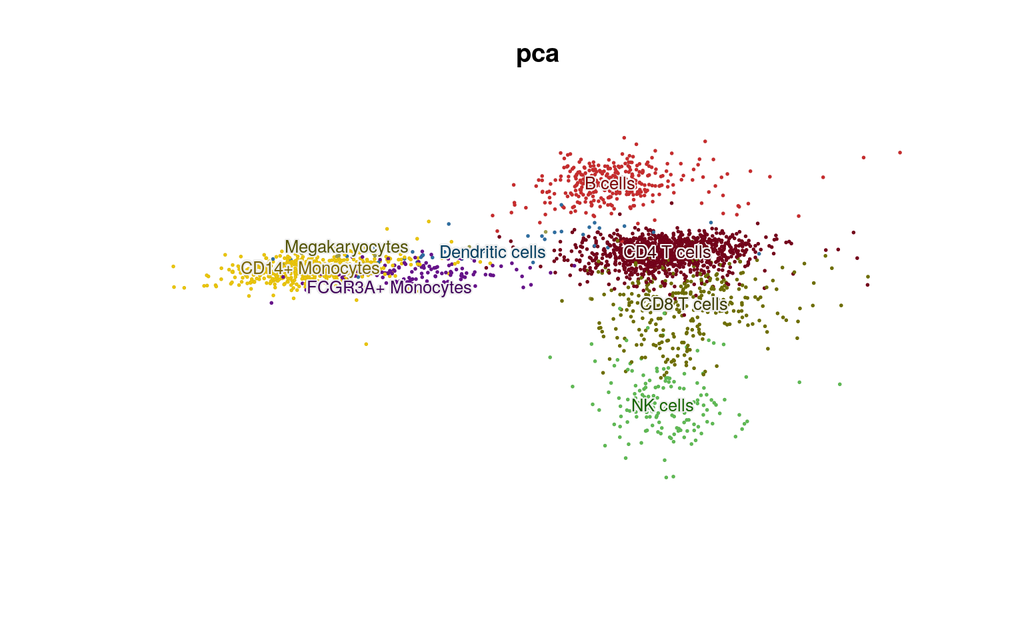

```r
plot.ACTIONet(ace, ace$louvain, reduction.slot = "pca", title = "pca")
```

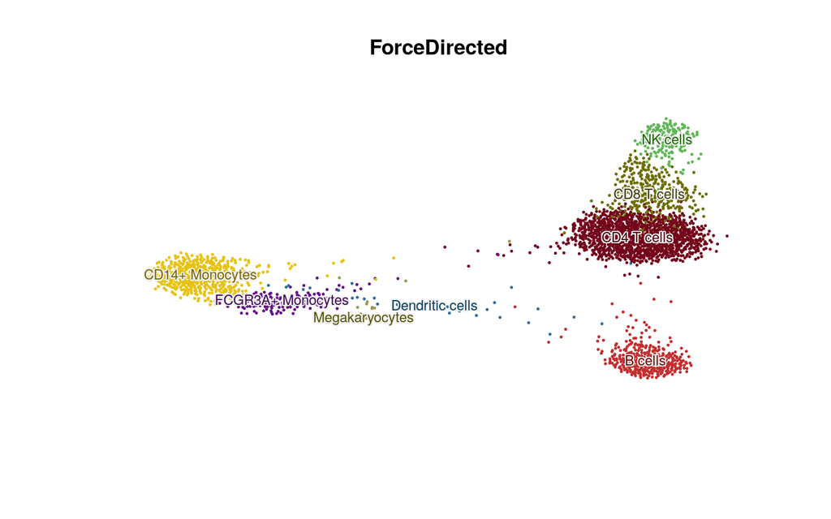

```r
plot.ACTIONet(ace, ace$louvain, reduction.slot = "draw_graph_fr", title = "ForceDirected")
```

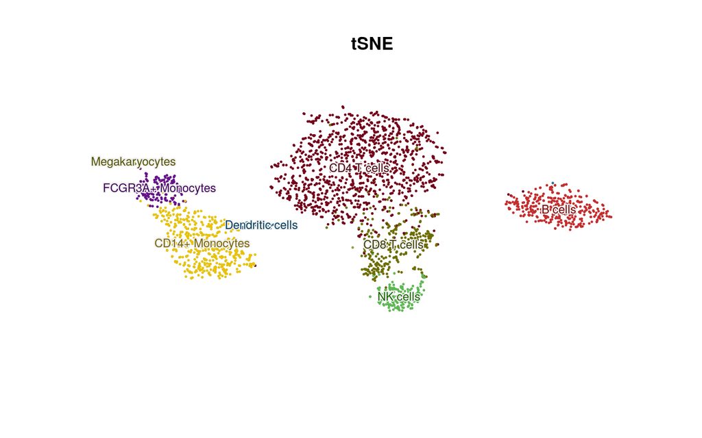

```r
plot.ACTIONet(ace, ace$louvain, reduction.slot = "tsne", title = "tSNE")
```

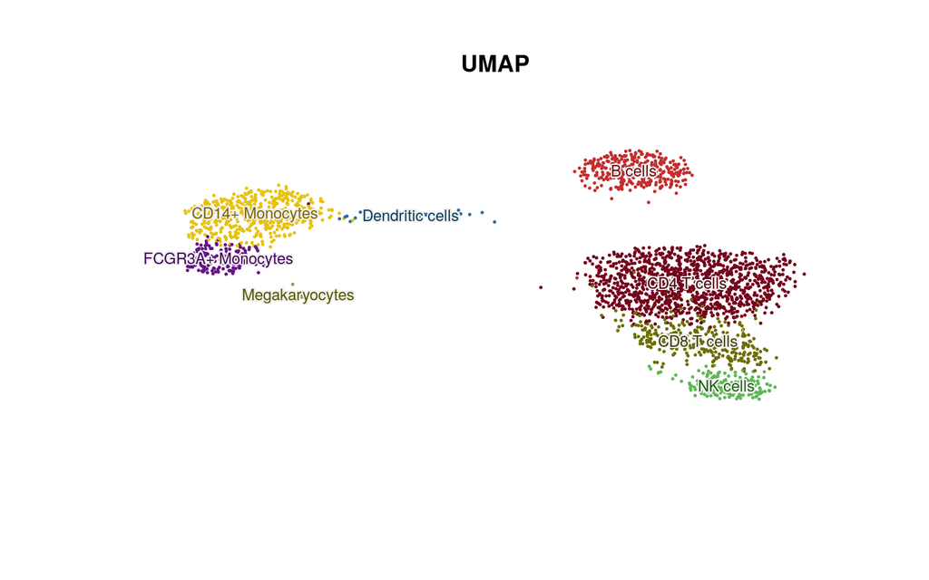

```r
plot.ACTIONet(ace, ace$louvain, reduction.slot = "umap", title = "UMAP")
```

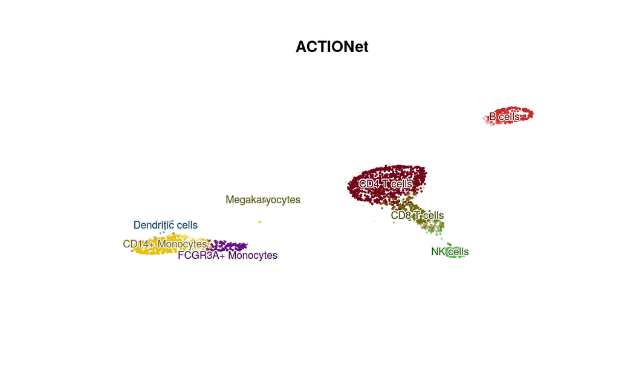

```r
plot.ACTIONet(ace, ace$louvain, reduction.slot = "ACTIONet2D", title = "ACTIONet",
    transparency.attr = ace$node_centrality, trans.fact = 1)
```

Shahin Mohammadi

Jose Davila-Velderrain

2020-04-26